# CDS Spatial exam code

# 1. Importing necessary libraries

```r
library(raster)
library(sp)
library(readr)
library(sf)
library(mapboxapi)
library(leaflet)
library(dplyr)
library(scales)
library(ggplot2)
library(htmlwidgets)
```

# 2. Setting up MapBox API token

FOr this chunk, feel free to replace my_token with your own API token

```r
# either paste it in directly, or in a txt file that you store locally and "ignore"
my_token <- "pk.eyJ1IjoiZnJlZGVuaCIsImEiOiJjbGV3cWh2eWswNjBrM3FuMGtrdWF3ejRxIn0.HnZxRawLqROSoooxNZCztA"
# my_token <- read_file("mytoken.txt")
mb_access_token(my_token, install = TRUE, overwrite = TRUE)
```

# 3. Spatial data transformation and wrangling

This section loads the wildfire risk data from EFFIS and preprocces it for spatial transformation and into a raster layer

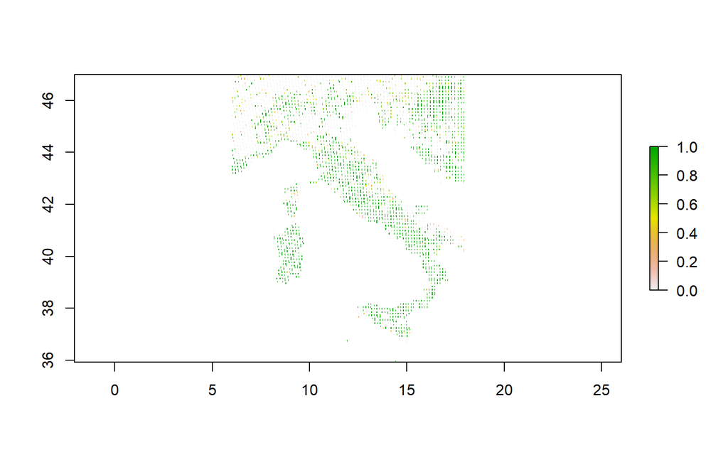

```r
# Reading the CSV file into the 'data' variable
data <- read_csv("../data/var-risk-aggr-l3p122_unit-dimensionless_stat-rank_class3-3.csv")

# Trimming leading and trailing whitespace from the column names using trimws() function
colnames(data) <- trimws(colnames(data))

# Filtering the data for Italy (and close neighbours) coordinates based on latitude, longitude, and non-NA fire risk values
italy_data <- data[data$`lat-1` >= 35.5 & data$`lat-1` <= 47 & data$`lon-1` >= 6 & data$`lon-1` <= 18 & !is.na(data$`Aggregated-fire-risk`), ]

# Converting the 'Aggregated-fire-risk' column to numeric type since there are NaN values in there
italy_data$`Aggregated-fire-risk` <- as.numeric(italy_data$`Aggregated-fire-risk`)

# Converting the filtered data to spatial features (sf) format, specifying the longitude and latitude columns
italy_sp <- st_as_sf(italy_data, coords = c("lon-1", "lat-1"), crs = 4326)

# Creating an empty raster layer
raster_layer <- raster()

# Setting the extent of the raster layer to match the extent of the spatial features
extent(raster_layer) <- extent(italy_sp)

# Setting the projection of the raster layer to WGS84 (since this is what is reffered to in the EFFIS documentation)
projection(raster_layer) <- CRS("+proj=longlat +datum=WGS84")

# Rasterizing the spatial features onto the raster layer using the 'Aggregated-fire-risk' column
raster_layer <- rasterize(italy_sp, raster_layer, field = italy_sp$`Aggregated-fire-risk`, na.rm = TRUE)

# Tesing the raster layer to see if it works
plot(raster_layer)
```

# 4. Creating Wildfire risk map from raster layer

The next chunk creates a ggplot2 map using geom_point()

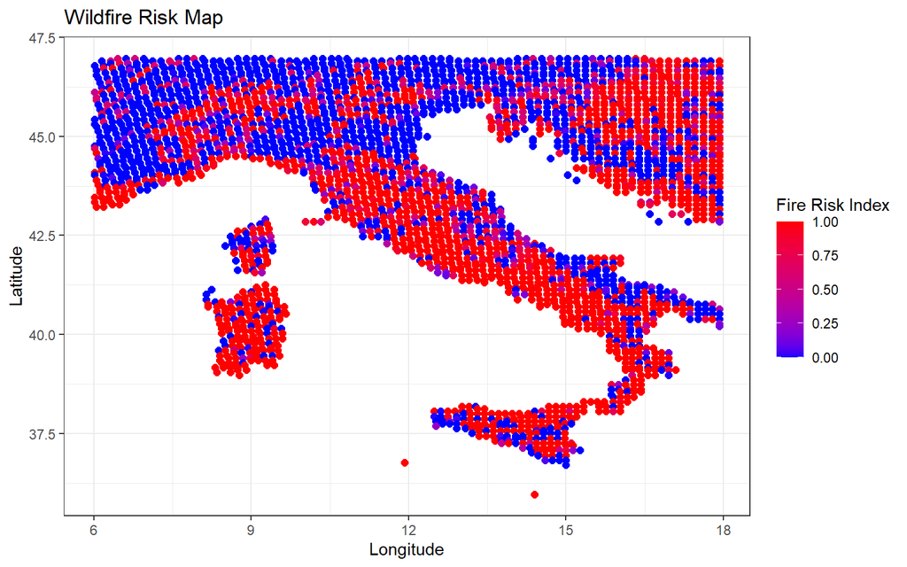

```r
# Converting raster layer to a data frame using rastertopoints() (represents each cell of the raster as a point with x, y coordinates and attribute values.)
raster_dfgg <- rasterToPoints(raster_layer)

# Converting to data frame. Ensuring that the x and y coordinates are included as separate columns.
raster_dfgg <- as.data.frame(raster_dfgg, xy = TRUE)

# Ploting using ggplot2 and geom_point() and adding informative legend
wildfire_risk_map <- ggplot(raster_dfgg, aes(x = x, y = y, color = layer)) +
    geom_point(size = 2) +
    scale_color_gradient(low = "blue", high = "red") +
    labs(title = "Wildfire Risk Map", x = "Longitude", y = "Latitude") +
    theme_bw() +
    guides(color = guide_colorbar(title = "Fire Risk Index"))
# Saving the map to the folder called "maps"
ggsave("../maps/wildfire_risk_map.png", wildfire_risk_map)
# Displaying the map
wildfire_risk_map
```

This map gives an overview of the overall wildfire risk in Italy using the raster layer created from the data gathered on EFFIS

# 5. Mapping the raster layer with Leaflet

In the following chunk, the raster layer created above is added to a Leaflet map in order to gain the ability to interact and explore the areas of high risk more closely.

```r
# Converting the raster layer to a data frame with x y coordinates. Using raster::as.data.frame ensures that the correct function is called from the correct package
raster_df <- raster::as.data.frame(raster_layer, xy = TRUE)

# Defining the color palette for the risk levels
colors <- c("blue", "red")

# Building the leaflet map
leaflet_wildfires <- leaflet() %>%                  # Initializing
  addTiles() %>%                              # Adding default tile layers for the map background
  addRasterImage(raster_layer,                # Adding the raster layer as an image overlay
                 colors = colors,             # Specifying the color palette
                 opacity = 0.7) %>%           # Setting the opacity of the raster image
  addLegend(position = "bottomright",         # Adding a legend to the bottom-right corner
            title = "Risk Level",             # Specifying the legend title
            colors = colors,                  # Specifying the legend colors
            labels = c("Low Risk", "High Risk"),  # Specifying the legend labels
            opacity = 0.5)                    # Setting the opacity of the legend

# Saving the Leaflet map as an HTML file
saveWidget(leaflet_wildfires, file = "../maps/leaflet_wildfires.html")

# Displaying the leaflet map
leaflet_wildfires
```

[interactive chart not shown]

# 6. Visualizing tourism data

The following section utilizes data gathered from Eurostat. It uses ggplot to visualize the data after it has been wrangled and preprocessed. ## 6.1 Line plot of tourism in Italy The following chunk of code visualizes tourism count in Italy between 2012 and 2021

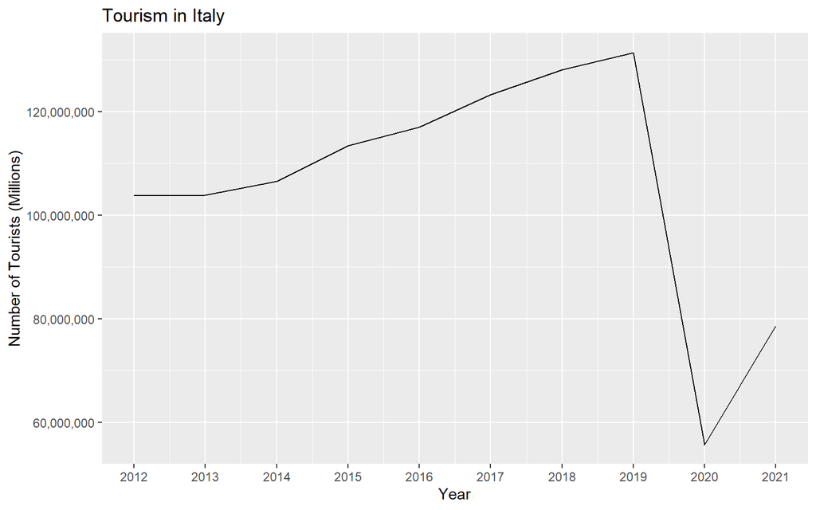

```r
# Reading the data CSV file containing tourism data from Eurostat into 'italy_tourism' variable
italy_tourism <- read.csv("../data/italy_tourism.csv")

# Subset the data to select only the rows where 'geo' column is "IT" (Italy)
subset_data <- italy_tourism[italy_tourism$geo == "IT", ]

# Creating the line plot using ggplot
# Using 'subset_data' as the data source and 'TIME_PERIOD' as the x-axis variable, 'OBS_VALUE' as the y-axis variable
Italy_line <- ggplot(subset_data, aes(x = TIME_PERIOD, y = OBS_VALUE)) +
    geom_line() +                                         # Adding a line to represent the data points
    labs(title = "Tourism in Italy",                      # Setting the title and labels for the plot
         x = "Year",
         y = "Number of Tourists (Millions)") +
    scale_y_continuous(labels = scales::comma) +          # Formatting the y-axis labels to use commas for thousands separator
    scale_x_continuous(breaks = seq(2012, 2021, 1)) +     # Setting the x-axis breaks (tick marks) to appear at every year between 2012 and 2021
    expand_limits(x = c(2012, 2021))                      # Expanding the x-axis limits to include the entire range from 2012 to 2021

# Saving the line plot to the "figs" folder
ggsave("../figs/Italy_line_plot.png", plot = Italy_line, width = 8, height = 6, dpi = 300)
# Displaying line plot
Italy_line
```

## 6.2 Wrangling regional tourism data

The following chunk of code preprocesses tourism data for each Italian region from Eurostat

```r
# Reading the CSV file into the 'tourism' variable
tourism <- read.csv("../data/tour_occ_arn3_page_linear.csv")
#"C:\\Users\\frede\\Desktop\\spatial-data\\tour_occ_arn3_page_linear.csv"

# Changing the mapping of old values to new values for the "geo" column for the sake of clarity in analysis
region_mapping <- c("ITC1" = "Piemonte",
                    "ITC2" = "Valle d'Aosta",
                    "ITC3" = "Liguria",
                    "ITC4" = "Lombardia",
                    "ITF1" = "Abruzzo",
                    "ITF2" = "Molise",
                    "ITF3" = "Campania",
                    "ITF4" = "Puglia",
                    "ITF5" = "Basilicata",
                    "ITF6" = "Calabria",
                    "ITG1" = "Sicilia",
                    "ITG2" = "Sardegna",
                    "ITH2" = "Trento",
                    "ITH3" = "Veneto",
                    "ITH4" = "Friuli-Venezia Giulia",
                    "ITH5" = "Emilia-Romagna",
                    "ITI1" = "Toscana",
                    "ITI2" = "Umbria",
                    "ITI3" = "Marche",
                    "ITI4" = "Lazio")

# Replacing the values in the "geo" column using the recode() function from dplyr
tourism <- tourism %>%
  mutate(geo = recode(geo, !!!region_mapping))
```

## 6.3 Visualizing regional tourism

The following section visualizes the count of tourists in each region in the year of 2019 since it was the year where tourism was at its highest before the COVID-1 lockdown of 2020 and 2021. This is why the line plot of 6.1 was of use.

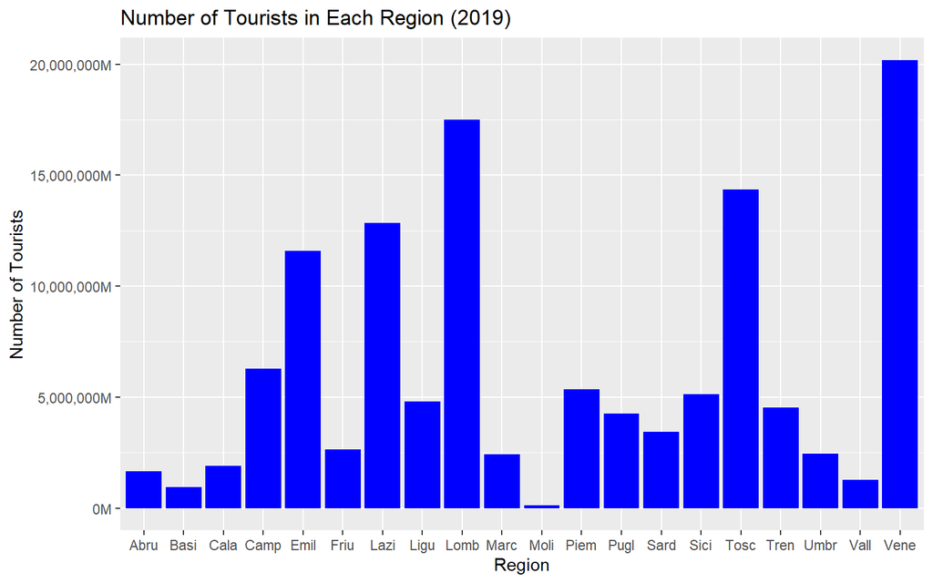

```r
# Filtering the data for the year 2019
filtered_data <- subset(tourism, TIME_PERIOD == 2019)

# Abbreviating region names to the first 4 letters
filtered_data$geo <- substr(filtered_data$geo, 1, 4)

# Creating a bar plot using ggplot2
regions_plot <- ggplot(data = filtered_data, aes(x = geo, y = OBS_VALUE)) + # Using 'filtered_data' as the data source and 'geo' as the x-axis variable, 'OBS_VALUE' as the y-axis variable
    geom_bar(stat = "identity", fill = "blue") +              # Adding bars to represent the data points
    labs(title = "Number of Tourists in Each Region (2019)",  # Assigning title and axis titles
         x = "Region",
         y = "Number of Tourists") +
    scale_y_continuous(labels = comma_format(big.mark = ",", suffix = "M"))   # Formatting the y-axis labels to use commas for thousands separator and adding "m" suffix to indicate millions

#Saving the bar plot to the folder called "figs"
ggsave("../figs/regions_bar_plot.png", plot = regions_plot, width = 8, height = 6, dpi = 300)
# Displaying bar plot
regions_plot
```

# 7. Mapping reachable areas using MapBoxAPI

The following section uses the MapBoxAPI package to create isochrones that showcase reachable areas from two different wildfire prone areas in 15 minutes in order to simulate a scenario where one might be caught in a location struck by wildfires. The code is designed so that if one choses to change the time variable for the isochrone calculations, i have created a list for that purpose, which contains 10, 15 and 20 minutes of driving, cycling or walking.

## 7.1 Reachable areas from San Pelagio

The first example takes the location of a personal experience as an example, San Pelagio, Trieste.

```r
# Defining color lists for visualization purposes further down
colors <- c("blue", "red")
colours <- c("orange", "green", "black")
```

```r
# Defining the coordinates for the location of San Pelagio
sp_coords <- c(13.687418, 45.765592)

# Geocoding the address of San Pelagio using the Mapbox API
san_p <- mb_geocode("San Pelagio. Trieste, 34011, Italy")

# Generating isochrones for driving with travel times of 10, 15, and 20 minutes from San Pelagio
sp_drive <- mb_isochrone(san_p,
                         profile = "driving",
                         time = c(10, 15, 20))

# Generating isochrones for cycling with travel times of 10, 15, and 20 minutes from San Pelagio
sp_cycle <- mb_isochrone(san_p,
                         profile = "cycling",
                         time = c(10, 15, 20))

# Generating isochrones for walking with travel times of 10, 15, and 20 minutes from San Pelagio
sp_walk <- mb_isochrone(san_p,
                        profile = "walking",
                        time = c(10, 15, 20))

# Creating a Leaflet map centered around San Pelagio with Mapbox tiles as the base layer also allowing for mb_ischrone to be added
sanp <- leaflet() %>%
    addMapboxTiles(style_id = "outdoors-v11",
                   username = "mapbox") %>%
    addRasterImage(raster_layer, colors = colors, opacity = 0.5) %>%                          # Adding the raster image (wildfire risk map) as an overlay with specified colors and opacity
    setView(lng = sp_coords[1], lat = sp_coords[2], zoom = 10.5) %>%                          # Setting the view of the map to San Pelagio's coordinates and desired zoom level
    addPolygons(data = sp_drive[2, ],                                                         # Adding polygons representing the driving isochrone for 15 minutes
                color = rev("orange"),
                fillColor = rev("orange"),
                fillOpacity = 0.4,
                opacity = 0.4,
                weight = 0.2) %>%
    addPolygons(data = sp_cycle[2, ],                                                         # Adding polygons representing the cycling isochrone for 15 minutes
                color = rev("green"),
                fillColor = rev("green"),
                fillOpacity = 0.4,
                opacity = 0.4,
                weight = 1) %>%
    addPolygons(data = sp_walk[2, ],                                                          # Adding polygons representing the walking isochrone for 15 minutes
                color = rev("black"),
                fillColor = rev("black"),
                fillOpacity = 0.4,
                opacity = 0.4,
                weight = 1) %>%
    addLegend(position = "bottomright",                                                       # Adding a legend for the transportation types (driving, cycling, walking) and their colors
              labels = c("driving", "cycling", "walking"),
              colors = colours,
              title = "Drive, cycle, walk-distance<br/> in 15 minutes<br/> from high risk location<br/> San Pelagio") %>%
    addLegend(position = "topright",                                                          # Adding a legend for the wildfire risk levels
              title = "wildfire risk Level",
              colors = colors,
              labels = c("Low Risk", "High Risk"),
              opacity = 0.5)

# Saving the map to the folder called "maps"
saveWidget(sanp, file = "../maps/SP_wildfire_risk_isochrone_map.html")

# Displaying the maps
sanp
```

[interactive chart not shown]

## 7.2 Mapping reachable areas from wildfire prone tourist area

The following example utilizes the insight generated from the visualisation on tourism data in Italian regions. It takes the second most visited region, Lombardia, and maps an area that is wildfire prone and heavily touristed, due to the nearby Lake Iseo to the south and and Lake Garda to the east. The mountainous and hilly geography of the area is also kept in mind in terms of possible routes calculated by the mb_isochrone function. It is designed to simulate a scenario of wildfires around the city of Darfo Boario Terme, and it provides an overview of routing option to escape the area as quick as possible.

```r
# Defining the coordinates for Lombardia
Lombardia_coords <- c(10.190965, 45.891964)

# Geocoding the address of Darfo Boario Terme using the Mapbox API
Lombardia <- mb_geocode("Darfo Boario Terme. Brescia, 25047, Italy")

# Generating isochrones for driving with travel times of 10, 15, and 20 minutes from Darfo Boario Terme
Lom_drive <- mb_isochrone(Lombardia,
                                 profile = "driving",
                                 time = c(10, 15, 20))
# Generating isochrones for cycling with travel times of 10, 15, and 20 minutes from Darfo Boario Terme
Lom_cycle <- mb_isochrone(Lombardia,
                                 profile = "cycling",
                                 time = c(10, 15, 20))
# Generating isochrones for walking with travel times of 10, 15, and 20 minutes from Darfo Boario Terme
Lom_walk <- mb_isochrone(Lombardia,
                                 profile = "walking",
                                 time = c(10, 15, 20))

# Creating a Leaflet map centered around Darfo Boario Terme with Mapbox tiles as the base layer also allowing for mb_ischrone to be added
Lom_leaflet <- leaflet() %>%
    addMapboxTiles(style_id = "outdoors-v11",
                   username = "mapbox") %>%
    setView(lng = Lombardia_coords[1], lat = Lombardia_coords[2], zoom = 10.5) %>%     # Setting view for Darfo Boario Terme and assigning the zoom level
    addRasterImage(raster_layer, colors = colors, opacity = 0.5) %>%
    addPolygons(data = Lom_drive[2, ],                                                 # Adding polygons representing the driving isochrone for 15 minutes
                color = rev("orange"),
                fillColor = rev("orange"),
                fillOpacity = 0.4,
                opacity = 0.4,
                weight = 0.2) %>%
    addPolygons(data = Lom_cycle[2, ],                                                 # Adding polygons representing the cycling isochrone for 15 minutes
                color = rev("green"),
                fillColor = rev("green"),
                fillOpacity = 0.4,
                opacity = 0.4,
                weight = 1) %>%
    addPolygons(data = Lom_walk[2, ],                                                  # Adding polygons representing the walking isochrone for 15 minutes
                color = rev("black"),
                fillColor = rev("black"),
                fillOpacity = 0.4,
                opacity = 0.4,
                weight = 1) %>%
    addLegend(position = "bottomright",                                                # Adding a legend for the transportation types (driving, cycling, walking) and their colors
              labels = c("driving", "cycling", "walking"),
              colors = colours,
              title = "Drive, cycle, walk-distance<br/> in 15 minutes<br/> from high risk location<br/> Darfo Boario Terme") %>%
    addLegend(position = "topright",                                                   # Adding a legend for the wildfire risk levels
              title = "wildfire risk Level",
              colors = colors,
              labels = c("Low Risk", "High Risk"),
              opacity = 0.5)

# Saving the map to the folder called "maps"
saveWidget(Lom_leaflet, file = "../maps/LOM_wildfire_risk_isochrone_map.html")

# Displaying the map
Lom_leaflet
```

[interactive chart not shown]